# PCA: sports analytics

Máster en Data Science y Big Data en Finanzas

AFI, 2022

# Motivation

**Sports analytics:** collection of relevant, historical, statistics that can provide a competitive advantage to a team or individual.

In this case study, we will analyze data from NBA and try to answer these questions

- How can we know who are the best NBA players based on basketball skills (not only points)?
- Do NBA players have skills that exceed their predefined positions (point guard, shooting guard, small forward, power forward, and center)?
- Can we help NBA coaches to make better decisions? Are they really making right decisions?

```r
# delete everything
rm(list=ls())

library(tidyverse)
library(GGally) # ggplot2-based visualization of correlations
library(factoextra) # ggplot2-based visualization of pca
```

## Load and prepare data

Currently, the NBA is composed of 30 teams (29 in the United States and 1 in Canada) with more than 500 players

Data from last season: https://www.basketball-reference.com/leagues/NBA_2021_per_game.html

The dataset contains skill performance of all the players (540) during the last season 2020-21

The glossary is in the web page. Performance is per game

```r
players.df = read.csv(file = "NBA.csv")

glimpse(players.df)
```

```
## Rows: 540
## Columns: 30
## $ Rk     <int> 1, 2, 3, 4, 5, 6, 7, 8, 9, 10, 11, 12, 13, 14, 15, 16, 17, 18, ~
## $ Player <chr> "Precious Achiuwa\\achiupr01", "Jaylen Adams\\adamsja01", "Stev~
## $ Pos    <chr> "PF", "PG", "C", "C", "C", "SG", "SG", "SG", "C", "PF", "PF", "~
## $ Age    <int> 21, 24, 27, 23, 35, 22, 22, 25, 22, 30, 27, 26, 23, 28, 36, 20,~
## $ Tm     <chr> "MIA", "MIL", "NOP", "MIA", "TOT", "PHO", "NOP", "MEM", "TOT", ~
## $ G      <int> 61, 7, 58, 64, 26, 15, 46, 50, 63, 23, 69, 61, 15, 57, 69, 47, ~
## $ GS     <int> 4, 0, 58, 64, 23, 0, 13, 38, 45, 14, 69, 61, 0, 3, 3, 34, 43, 0~
## $ MP     <dbl> 12.1, 2.6, 27.7, 33.5, 25.9, 3.1, 21.9, 25.2, 29.6, 18.9, 27.3,~
## $ FG     <dbl> 2.0, 0.1, 3.3, 7.1, 5.4, 0.2, 4.2, 3.5, 4.7, 1.7, 4.5, 10.3, 0.~
## $ FGA    <dbl> 3.7, 1.1, 5.3, 12.5, 11.4, 0.8, 10.0, 8.3, 7.7, 4.3, 9.5, 18.0,~
## $ FG.    <dbl> 0.544, 0.125, 0.614, 0.570, 0.473, 0.250, 0.419, 0.418, 0.618, ~
## $ X3P    <dbl> 0.0, 0.0, 0.0, 0.0, 1.2, 0.1, 1.7, 2.1, 0.1, 0.3, 1.4, 1.1, 0.0~
## $ X3PA   <dbl> 0.0, 0.3, 0.1, 0.1, 3.1, 0.6, 4.8, 5.5, 0.3, 1.6, 3.8, 3.6, 0.0~
```

[output cut: 17 more lines]

## Missing values

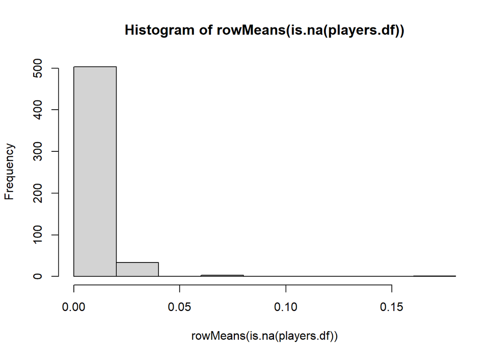

```r
hist(rowMeans(is.na(players.df)))
```

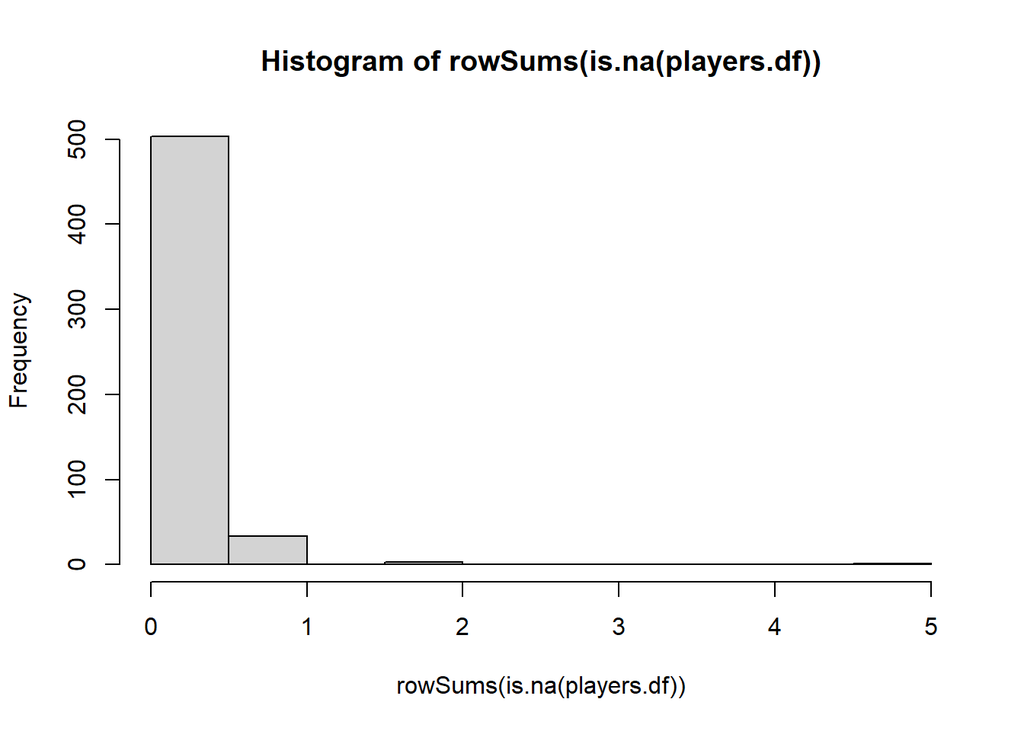

```r
hist(rowSums(is.na(players.df)))
```

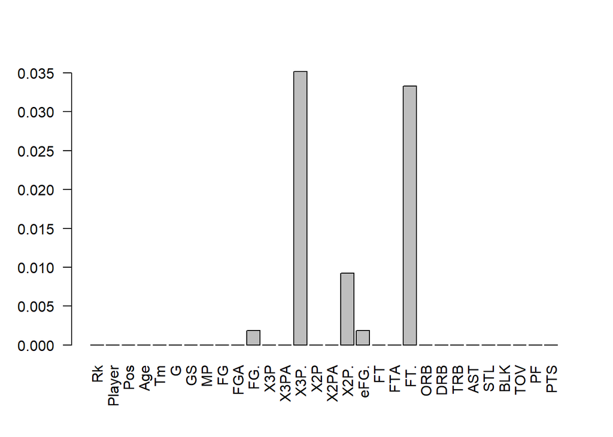

```r
barplot(colMeans(is.na(players.df)), las=2)
```

Conclusions? What can we do?

## Some feature engineering

We are going to skip the following variables:

- Rk: just the rank
- Player: the name
- Pos: position
- Age
- Tm: team
- G and GS: games played and started (they depend on the coach, not the player’s skills)
- MP: minutes played per game (they depend on the coach, not the player’s skills)

```r
players.df <- players.df %>% filter(G > 2)
nba <- players.df[,9:ncol(players.df)]

names = players.df[,2]
pos = players.df[,3]
team = players.df[,5]
gp = players.df[,6]
min = players.df[,8]
points = players.df[,30]

dim(nba)
```

```
## [1] 531  22
```

```r
summary(nba)
```

```
##        FG              FGA              FG.              X3P
##  Min.   : 0.000   Min.   : 0.200   Min.   :0.0000   Min.   :0.000
##  1st Qu.: 1.600   1st Qu.: 3.650   1st Qu.:0.4040   1st Qu.:0.300
##  Median : 2.800   Median : 6.100   Median :0.4420   Median :0.800
##  Mean   : 3.316   Mean   : 7.218   Mean   :0.4489   Mean   :1.015
##  3rd Qu.: 4.600   3rd Qu.: 9.900   3rd Qu.:0.4965   3rd Qu.:1.600
##  Max.   :11.200   Max.   :23.000   Max.   :1.0000   Max.   :5.300
##
##       X3PA             X3P.             X2P              X2PA
##  Min.   : 0.000   Min.   :0.0000   Min.   : 0.000   Min.   : 0.000
##  1st Qu.: 1.000   1st Qu.:0.2772   1st Qu.: 0.900   1st Qu.: 1.800
##  Median : 2.300   Median :0.3410   Median : 1.800   Median : 3.500
##  Mean   : 2.833   Mean   :0.3159   Mean   : 2.304   Mean   : 4.391
##  3rd Qu.: 4.350   3rd Qu.:0.3897   3rd Qu.: 3.200   3rd Qu.: 5.950
##  Max.   :12.700   Max.   :1.0000   Max.   :10.200   Max.   :16.800
##                   NA's   :17
##       X2P.             eFG.              FT             FTA
##  Min.   :0.0000   Min.   :0.0000   Min.   :0.000   Min.   : 0.00
##  1st Qu.:0.4640   1st Qu.:0.4840   1st Qu.:0.500   1st Qu.: 0.70
##  Median :0.5130   Median :0.5250   Median :0.900   Median : 1.30
##  Mean   :0.5114   Mean   :0.5162   Mean   :1.375   Mean   : 1.78
##  3rd Qu.:0.5740   3rd Qu.:0.5670   3rd Qu.:1.800   3rd Qu.: 2.25
##  Max.   :1.0000   Max.   :1.0000   Max.   :9.200   Max.   :10.70
##  NA's   :2
##       FT.              ORB              DRB              TRB
##  Min.   :0.0000   Min.   :0.0000   Min.   : 0.000   Min.   : 0.000
##  1st Qu.:0.6903   1st Qu.:0.3000   1st Qu.: 1.500   1st Qu.: 1.950
##  Median :0.7770   Median :0.6000   Median : 2.500   Median : 3.200
##  Mean   :0.7552   Mean   :0.8171   Mean   : 2.836   Mean   : 3.653
##  3rd Qu.:0.8450   3rd Qu.:1.0500   3rd Qu.: 3.800   3rd Qu.: 4.800
##  Max.   :1.0000   Max.   :4.7000   Max.   :10.100   Max.   :14.300
##  NA's   :13
##       AST              STL              BLK              TOV
##  Min.   : 0.000   Min.   :0.0000   Min.   :0.0000   Min.   :0.000
##  1st Qu.: 0.700   1st Qu.:0.3000   1st Qu.:0.1000   1st Qu.:0.500
##  Median : 1.400   Median :0.6000   Median :0.3000   Median :0.900
##  Mean   : 2.007   Mean   :0.6273   Mean   :0.4164   Mean   :1.087
##  3rd Qu.: 2.550   3rd Qu.:0.9000   3rd Qu.:0.6000   3rd Qu.:1.400
##  Max.   :11.700   Max.   :2.1000   Max.   :3.4000   Max.   :4.800
##
##        PF             PTS
##  Min.   :0.000   Min.   : 0.000
##  1st Qu.:1.100   1st Qu.: 4.250
##  Median :1.700   Median : 7.400
##  Mean   :1.637   Mean   : 9.024
##  3rd Qu.:2.100   3rd Qu.:12.450
##  Max.   :4.000   Max.   :32.000
##
```

Take care: there are some redundant variables, for instance

- FG, FGA, and percentage (FG.)
- etc.

We can also remove variable PTS, because PTS=FT+X2P+X3P

The decision about the final variables to consider (input) is very important and will affect the output

Enter here your variables to measure skill performance:

```r
nba = nba[,-c(3,6,9,10,13,16,22)]

dim(nba)
```

```
## [1] 531  15
```

# Descriptive Analysis

Our input has dimension $p=15$, that implies $2^p$ different relations between the variables.

Dimension 1: univariate analysis for all 15 variables

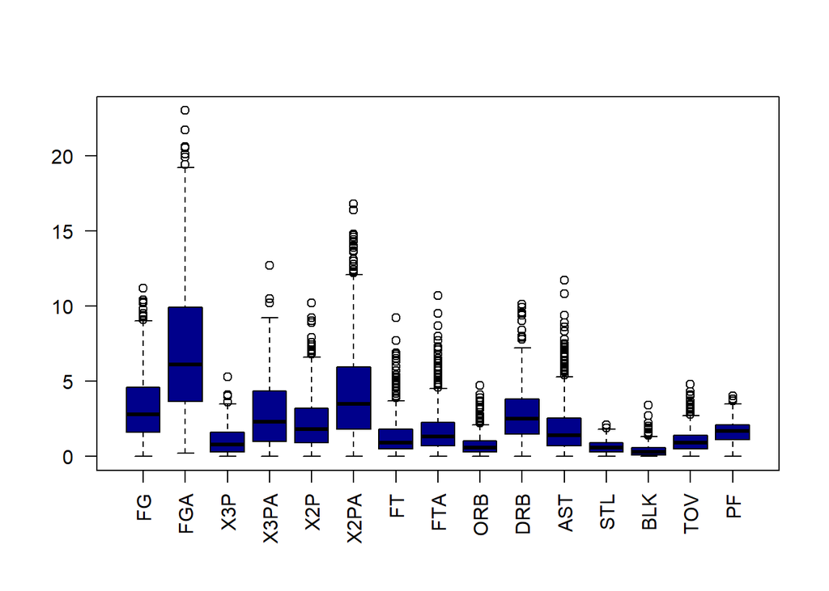

```r
boxplot(nba, las=2, col="darkblue")
```

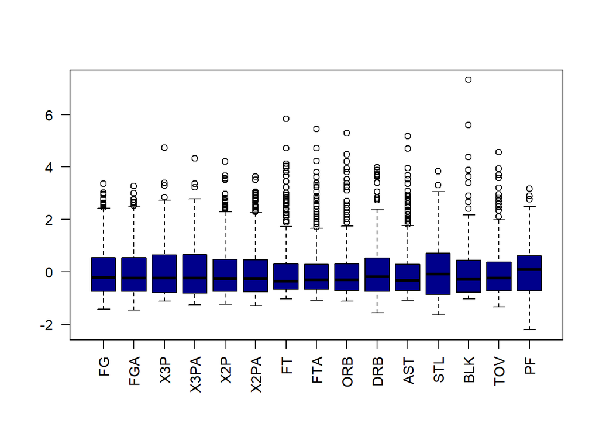

```r
# scale or not to scale?
boxplot(scale(nba), las=2, col="darkblue")
```

Dimension 2: bivariate analysis (scatter plots), in total 105

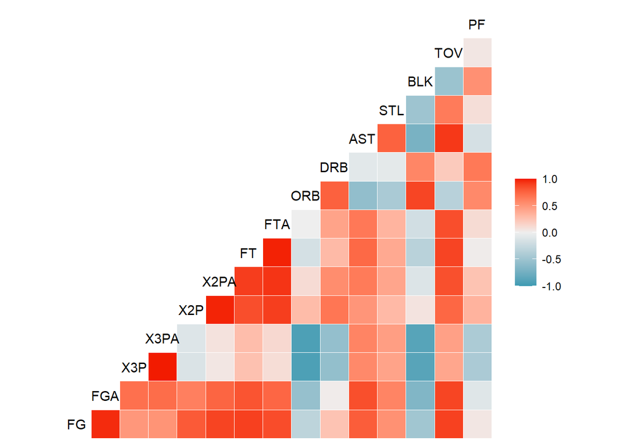

```r
# enter here your code
R =cor(nba)
ggcorr(R)
```

Conclusions?

Dimension 3: proportional to $15^3$ relations, but no way to obtain information… This is why we need an analytical tool to reduce the dimension

Finally, note there are variables highly correlated, especially the most related ones (like ftm and fta)

# PCA

From dimension 15 to dimension 2

```r
pca = prcomp(nba, scale = T)
summary(pca)
```

```
## Importance of components:
##                           PC1    PC2     PC3     PC4     PC5     PC6     PC7
## Standard deviation     3.0550 1.5544 1.02694 0.81682 0.61632 0.57548 0.55139
## Proportion of Variance 0.6222 0.1611 0.07031 0.04448 0.02532 0.02208 0.02027
## Cumulative Proportion  0.6222 0.7833 0.85357 0.89805 0.92338 0.94546 0.96572
##                            PC8     PC9    PC10    PC11   PC12    PC13    PC14
## Standard deviation     0.48252 0.37788 0.30075 0.16326 0.1092 0.09588 0.01495
## Proportion of Variance 0.01552 0.00952 0.00603 0.00178 0.0008 0.00061 0.00001
## Cumulative Proportion  0.98125 0.99077 0.99680 0.99857 0.9994 0.99998 1.00000
##                            PC15
## Standard deviation     0.007642
## Proportion of Variance 0.000000
## Cumulative Proportion  1.000000
```

Insights?

This is the same, but using mathematical format; here, eigenvalues denote variances and eigenvectors denote loadings:

```r
eigen(R)
```

```
## eigen() decomposition
## $values
##  [1] 9.332868e+00 2.416145e+00 1.054596e+00 6.671970e-01 3.798488e-01
##  [6] 3.311756e-01 3.040342e-01 2.328256e-01 1.427962e-01 9.045238e-02
## [11] 2.665352e-02 1.193249e-02 9.192579e-03 2.235273e-04 5.840514e-05
##
## $vectors
##             [,1]        [,2]        [,3]        [,4]         [,5]        [,6]
##  [1,] -0.3172975 -0.05140488  0.01621462  0.17118807 -0.131365202  0.12311027
##  [2,] -0.3121440 -0.14599259 -0.01441861  0.14265459 -0.098861170  0.08241078
##  [3,] -0.1966404 -0.41814947 -0.38866755  0.24435555 -0.033305046  0.08478770
##  [4,] -0.2028321 -0.42216685 -0.36889949  0.21069823  0.001047489  0.04799852
##  [5,] -0.3011871  0.13760158  0.20718959  0.09573482 -0.148535078  0.11296369
##  [6,] -0.3057498  0.07536240  0.22599851  0.06070457 -0.142263975  0.08448486
##  [7,] -0.2895623 -0.01711226  0.30450947  0.20079222  0.314093278 -0.13749011
```

[output cut: 40 more lines]

## How many components?

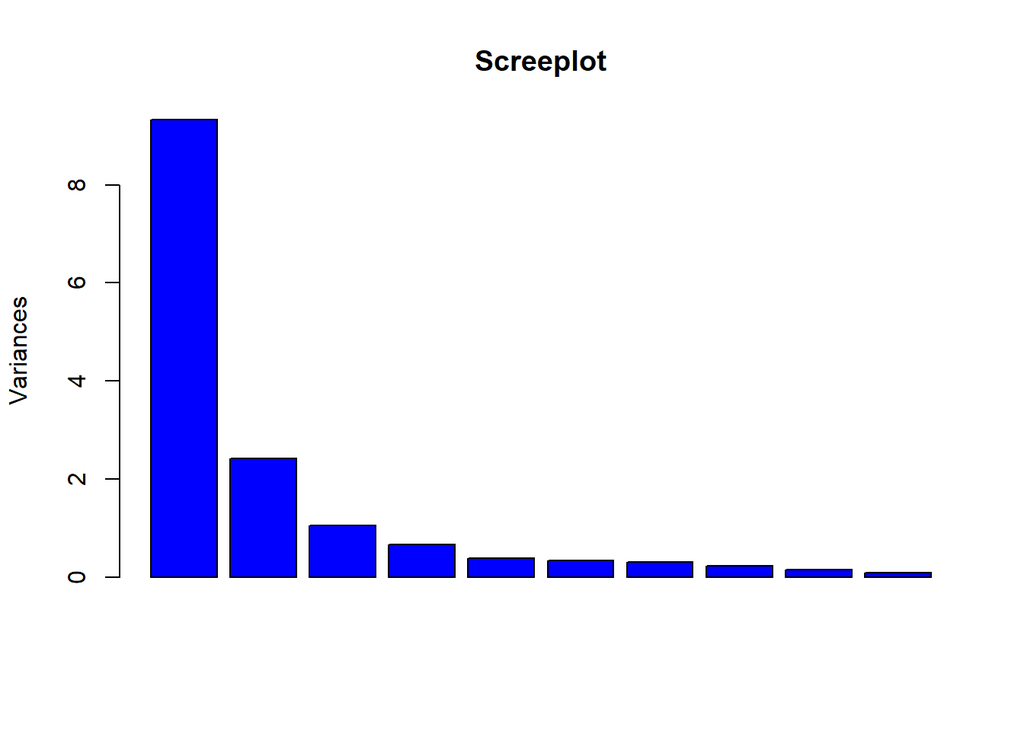

```r
screeplot(pca,main="Screeplot",col="blue",type="barplot",pch=19)
```

Nicer with factoextra package:

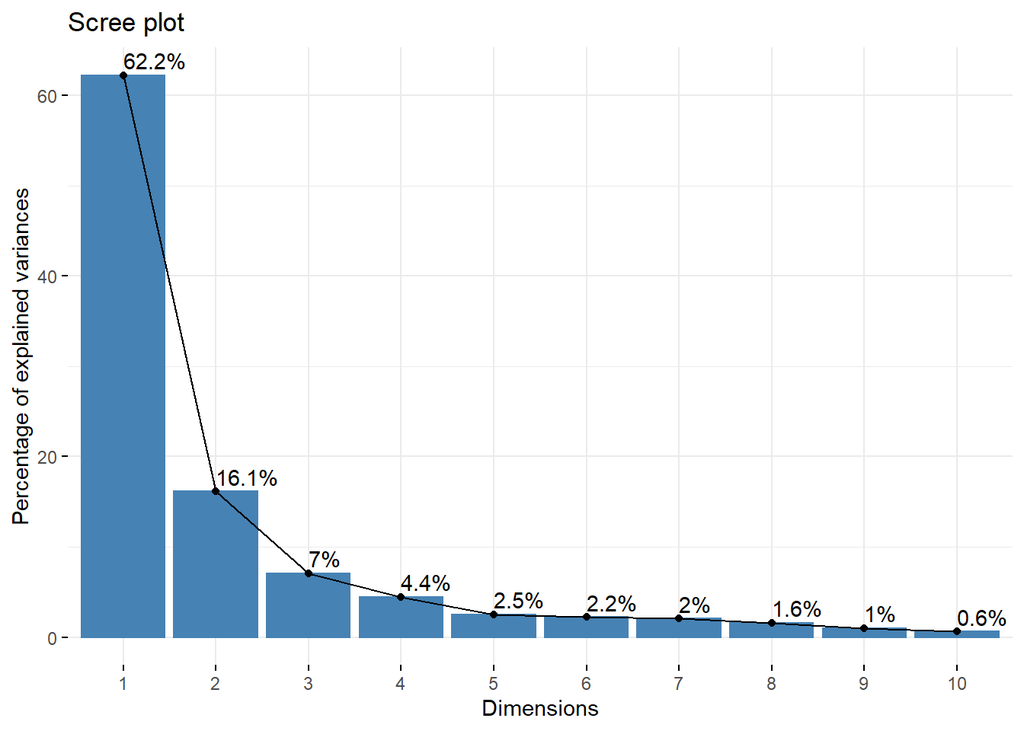

```r
fviz_screeplot(pca, addlabels = TRUE)
```

Note with 2 components we explain 78% of variability

## Interpretation of components

First component:

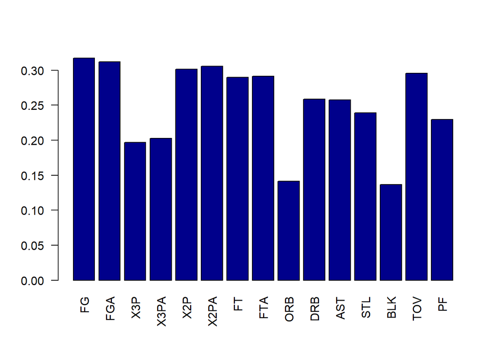

```r
barplot(pca$rotation[,1], las=2, col="darkblue")
```

Any hint for the meaning of the 1st PC?

Note the sum of the squared loadings (eigenvectors) is equal to 1

```r
sum(pca$rotation[,1]^2)
```

```
## [1] 1
```

That means squared loadings are easier to interpret than the loadings

I.e. they are like percentages (numbers between 0 and 1)

So let’s plot squared loadings instead

They are called contribution of variables to components

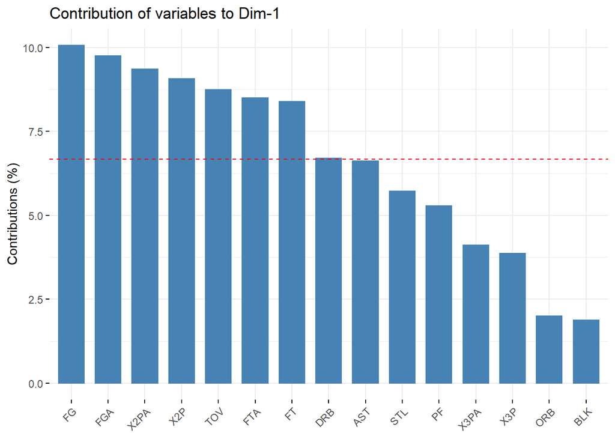

```r
fviz_contrib(pca, choice = "var", axes = 1)
```

The red dashed line on the graph above indicates the expected average contribution

If the contribution of the variables were uniform, the expected value would be 1/length(variables) = 1/15 = 6.6%

Now we can rank the players by their first PC scores: best historical players in terms of performance:

```r
# The best
names[order(pca$x[,1])][(length(names)-5):length(names)]
```

```
## [1] "Nikola Jokic\\jokicni01"          "Bradley Beal\\bealbr01"
## [3] "Luka Doncic\\doncilu01"           "Joel Embiid\\embiijo01"
## [5] "Russell Westbrook\\westbru01"     "Giannis Antetokounmpo\\antetgi01"
```

```r
# The worst
names[order(pca$x[,1])][1:10]
```

```
##  [1] "Greg Whittington\\whittgr01"  "Theo Pinson\\pinsoth01"
##  [3] "Jaylen Adams\\adamsja01"      "Brian Bowen\\bowenbr02"
##  [5] "Terrance Ferguson\\fergute01" "Jared Harper\\harpeja01"
##  [7] "Ty-Shon Alexander\\alexaty01" "Noah Vonleh\\vonleno01"
##  [9] "Nate Darling\\darlina01"      "Nick Richards\\richani01"
```

Nikola Jokić was the Most Valuable Player in the season: https://www.basketball-reference.com/leagues/NBA_2021_leaders.html

Second component:

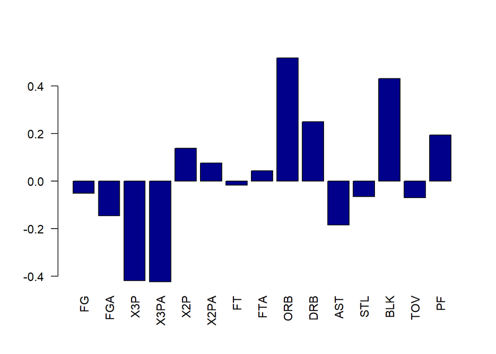

```r
barplot(pca$rotation[,2], las=2, col="darkblue")
```

Any insight about this component? Forward vs Guard?

Maybe we can get more insights by ranking the players using this component:

```r
names[order(pca$x[,2])][1:6]
```

```
## [1] "Stephen Curry\\curryst01"   "Damian Lillard\\lillada01"
## [3] "Devonte' Graham\\grahade01" "Buddy Hield\\hieldbu01"
## [5] "Kemba Walker\\walkeke02"    "CJ McCollum\\mccolcj01"
```

```r
names[order(pca$x[,2])][(length(names)-5):length(names)]
```

```
## [1] "Jakob Poeltl\\poeltja01"      "Andre Drummond\\drumman01"
## [3] "Jonas Valanciunas\\valanjo01" "Mitchell Robinson\\robinmi01"
## [5] "Rudy Gobert\\goberru01"       "Clint Capela\\capelca01"
```

Contribution of variables to second component:

Take care because we loose the sign (to get contribution in percentage)

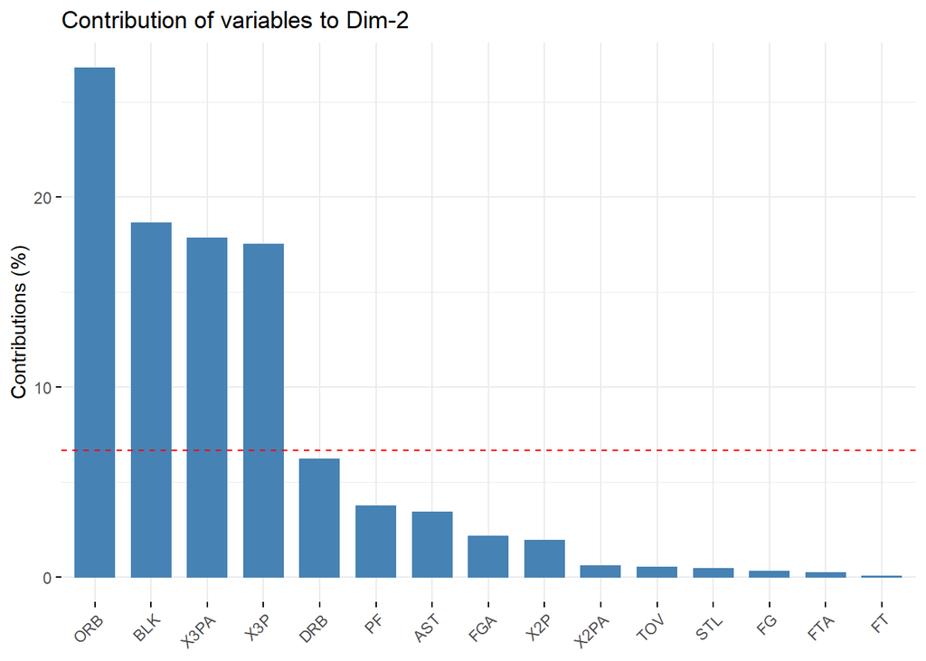

```r
fviz_contrib(pca, choice = "var", axes = 2)
```

Once we have interpreted the meaning of the first two components, let’s see the contribution of each player to components

For the $i$-th player and first component, the contribution is: $z_{1,i}^2 / \lambda_1 / n$, which is a number between 0 and 1

```r
head(get_pca_ind(pca)$contrib[,1]) # this is in %, that is between 0 and 100
```

```
##          1          2          3          4          5          6
## 0.05635933 0.44531666 0.01878075 0.67527409 0.04722503 0.41317461
```

```r
head((pca$x[,1]^2)/(pca$sdev[1]^2))/dim(nba)[1] # this is between 0 and 1
```

```
## [1] 0.0005635933 0.0044531666 0.0001878075 0.0067527409 0.0004722503
## [6] 0.0041317461
```

Let’s visualize the top-100 players contributions to first component (global performance):

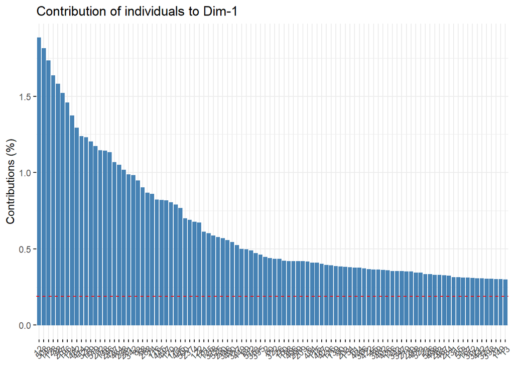

```r
fviz_contrib(pca, choice = "ind", axes = 1, top=100)
```

Let’s see the first names:

```r
names[order(get_pca_ind(pca)$contrib[,1],decreasing=T)][1:10]
```

```
##  [1] "Giannis Antetokounmpo\\antetgi01" "Russell Westbrook\\westbru01"
##  [3] "Joel Embiid\\embiijo01"           "Luka Doncic\\doncilu01"
##  [5] "Bradley Beal\\bealbr01"           "Nikola Jokic\\jokicni01"
##  [7] "James Harden\\hardeja01"          "Stephen Curry\\curryst01"
##  [9] "Karl-Anthony Towns\\townska01"    "Julius Randle\\randlju01"
```

```r
# It is very similar to names[order(pca$x[,1])][1:10] but in percentage
```

Finally, let’s make a zoom to see the top-20 players in contributions:

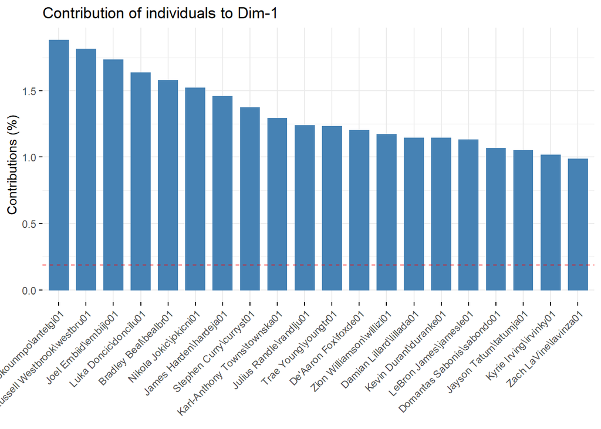

```r
names_z1 = names[order(get_pca_ind(pca)$contrib[,1],decreasing=T)]
fviz_contrib(pca, choice = "ind", axes = 1, top=20)+scale_x_discrete(labels=names_z1)
```

## The Biplot

Biplot: observations and variables in same graph (using first 2 components)

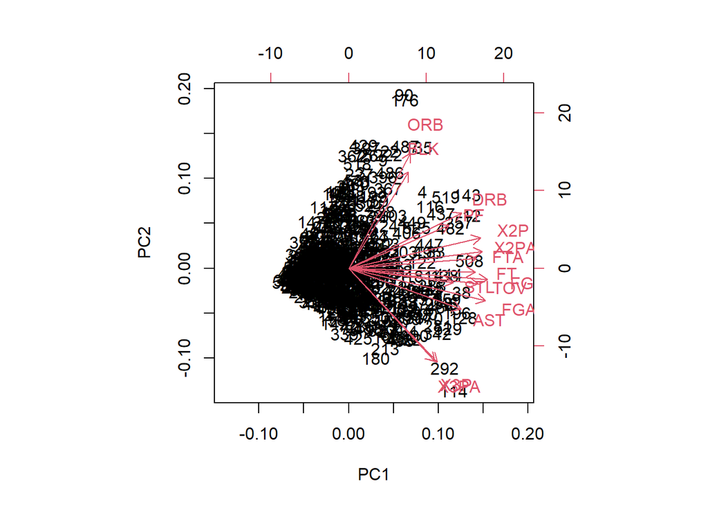

```r
biplot(pca)
```

Not informative in this case: too many players

Nicer and using contributions (instead of loadings), without players:

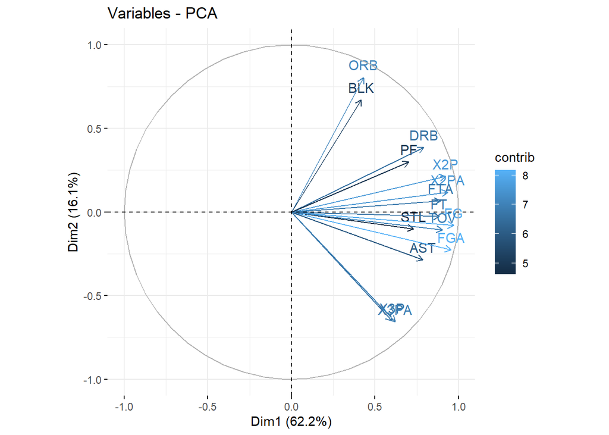

```r
fviz_pca_var(pca, col.var = "contrib")
```

Nicer but again too much information:

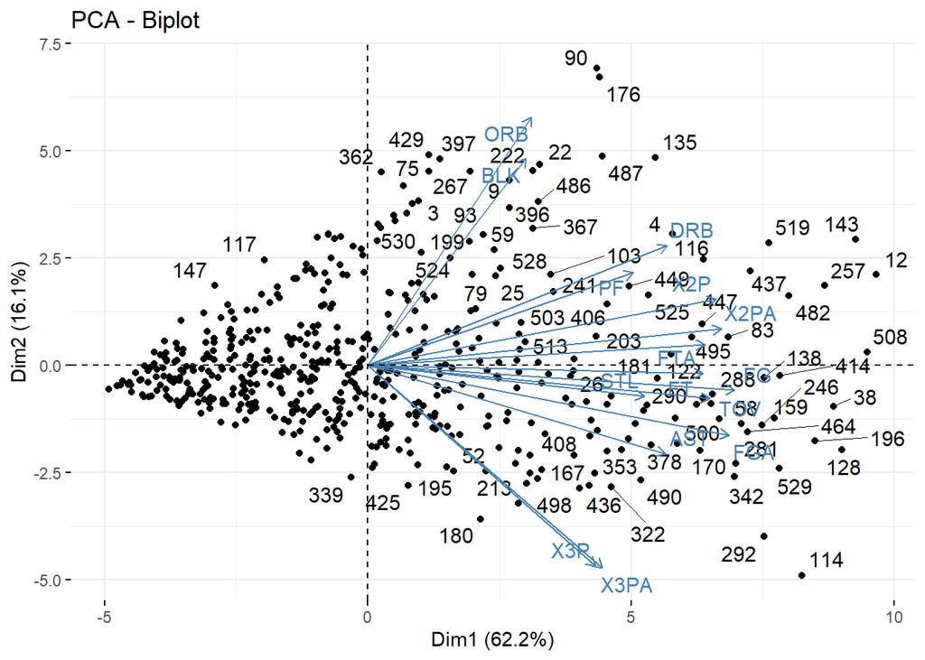

```r
fviz_pca_biplot(pca, repel = TRUE)
```

## The Scores

Remember, for the $j$-th principal component: $Z_j = X a_j$, $a_j$ denotes the loadings, and $Z_j$ denotes the scores

Let’s plot the first two scores, using colors for minutes played:

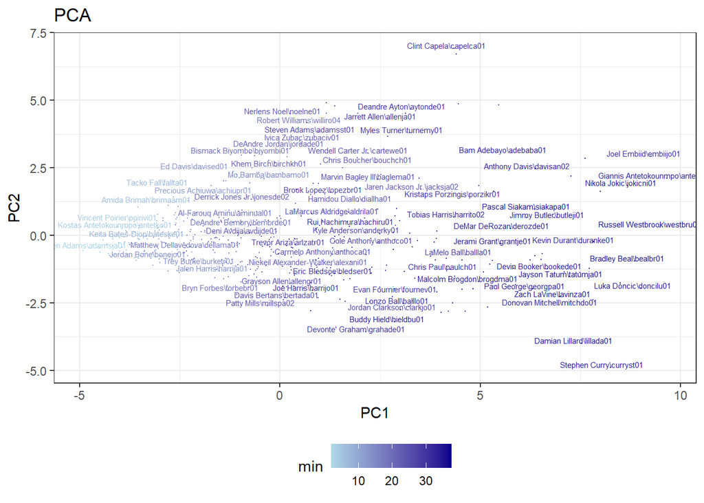

```r
data.frame(z1=pca$x[,1],z2=pca$x[,2]) %>%
  ggplot(aes(z1,z2,label=names,color=min)) + geom_point(size=0) +
  labs(title="PCA", x="PC1", y="PC2") +
  theme_bw() + scale_color_gradient(low="lightblue", high="darkblue")+theme(legend.position="bottom") + geom_text(size=2, hjust=0.6, vjust=0, check_overlap = TRUE)
```

The first two PCs seem independent, but this is not always the same. What is true is that they are always uncorrelated.

The first component is highly correlated with minutes (decided by coaches)

The same, but using colors for games played:

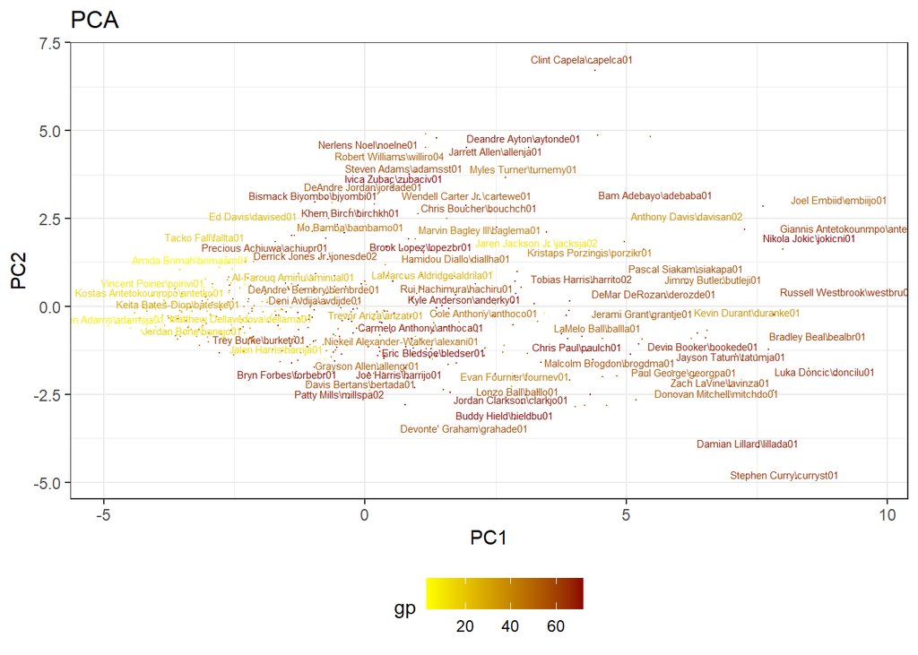

```r
data.frame(z1=pca$x[,1],z2=pca$x[,2]) %>%
  ggplot(aes(z1,z2,label=names,color=gp)) + geom_point(size=0) +
  labs(title="PCA", x="PC1", y="PC2") +
  theme_bw() + scale_color_gradient(low="yellow", high="darkred")+theme(legend.position="bottom") + geom_text(size=2, hjust=0.6, vjust=0, check_overlap = TRUE)
```

Insights?

Which are the teams with the best players?

```r
data.frame(z1=pca$x[,1],team=team) %>% group_by(team) %>% summarise(mean=mean(z1)) %>% arrange(desc(mean))
```

```
## # A tibble: 31 x 2
##    team   mean
##    <chr> <dbl>
##  1 HOU   1.27
##  2 MIN   0.758
##  3 NOP   0.616
##  4 WAS   0.491
##  5 TOR   0.490
##  6 MIA   0.420
##  7 OKC   0.349
##  8 ATL   0.330
##  9 GSW   0.261
## 10 BOS   0.256
## # ... with 21 more rows
```

Houston Rockets has the best overall players

Other view: are the better players playing more minutes in a game?

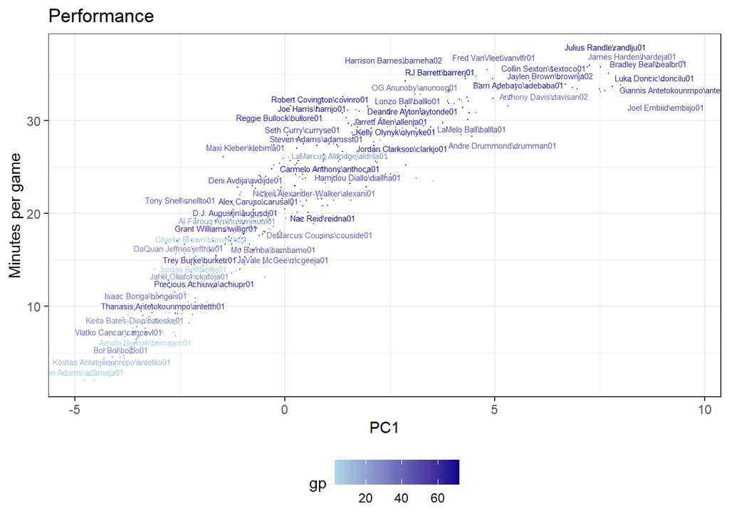

```r
data.frame(z1=pca$x[,1],z2=min) %>%
  ggplot(aes(z1,z2,label=names,color=gp)) + geom_point(size=0) +
  labs(title="Performance", x="PC1", y="Minutes per game") +
  scale_color_gradient(low="lightblue", high="darkblue") +
  theme_bw() + theme(legend.position="bottom") + geom_text(size=2, hjust=0.6, vjust=0, check_overlap = TRUE)
```

Yes, but non-linear… why?

Are the better players playing more games?

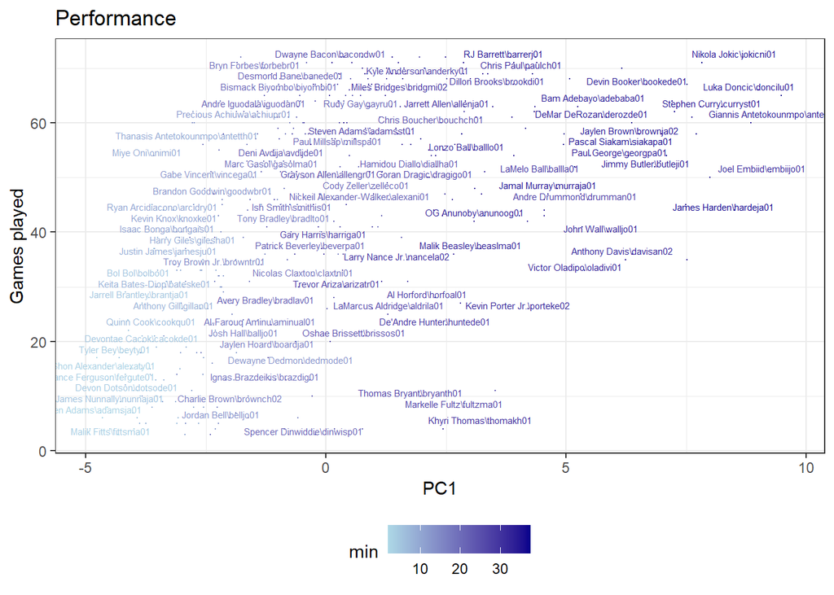

```r
data.frame(z1=pca$x[,1],z2=gp) %>%
  ggplot(aes(z1,z2,label=names,color=min)) + geom_point(size=0) +
  labs(title="Performance", x="PC1", y="Games played") +
  scale_color_gradient(low="lightblue", high="darkblue") +
  theme_bw() + theme(legend.position="bottom") + geom_text(size=2, hjust=0.6, vjust=0, check_overlap = TRUE)
```

Somehow, but not too much… why?